# 前海人寿个险代理人评分卡模型

liwb

2018年6月22日

# 前言

## 背景说明

### 个险渠道是寿险公司重要的业务渠道之一，而个险渠道的壮大主要取决于营销员队伍，在过去的十几年中，一直以人海战术为主要模式，行业个险代理人呈现出高增员高脱落的态势，随着时代的发展，行业也在思考这种模式是否仍然有效？不少寿险公司逐渐探索精英代理人路线，即不再专注于代理人数量，而是寻找高素质，可持续为公司创造保费收入的代理人。本文拟应用本司的代理人数据（约5.1W名，包括已经离职的）探索绩优代理人的属性，以便在以后的增员中做一定的参考。

## 整体思路

### 从数据平台抽取数据，利用sas进行前期的数据清洗，形成模型的训练数据，再做逻辑回归，最后利用WOE转换形成评分卡。

## 模型训练数据来源说明

### 1.fig,为二分类的响应变量，表示营销员入司后是否为绩优的人员（1为绩优，0为非绩优）。绩优的条件有两方面，一是入司后的累计业绩（FYB新折）大于等于其司龄*8000，即平均每月为公司贡献8kp的保费；二是其累计期交保单（承保日期在2017年3月31日及之前的）在2018年5月31日仍然生效的比例需大于等于70%，即累计13月保费继续率不低于70per。

### 2.age_com,为营销员入司时的年龄，是自变量中唯一的连续型数值变量，因考虑到我司已成立已超过5年了，用其现在的年龄会有误差，故选择其入司时的年龄，通过身份证号码与其签约时间计算而来。

### 3.education，为营销员的学历背景，共有中技，中专，高中，大专，本科，研究生，博士7个水平，在逻辑回归中，属性变量的值通常为两种水平，这里将中技，中专，高中和大专分为一类，值为0，本科，研究生，博士分为一类，值为1。

### 4.sex，为营销员的性别，1为男性，0为女性。

### 5.ifnative，1表示营销员的籍贯与分公司所在的行政区域是一致的，0表示反之，例如，深圳分公司则判断其身份证号前六位是否为440300；广东分公司则判断其身份证号前两位是否为44。

### 6.其他说明，营销员包含了已经离职的；非中国大陆居民的营销员其id难以处理，作直接删除这种观测值。

## 一、读入已清洗完毕的训练数据

```r
traindata<-read.csv("营销员分析数据源.csv");
head(traindata,num=5L);
```

```
##   education age_com sex marry fig ifnative
## 1         0      41   0     1   1        1
## 2         0      43   0     1   0        1
## 3         0      44   1     1   0        1
## 4         0      47   0     1   0        1
## 5         0      49   0     1   0        1
## 6         0      34   0     1   0        0
```

## 二、变量分析

### 1.单变量分析

### >在五个自变量中只有年龄是连续型随机变量

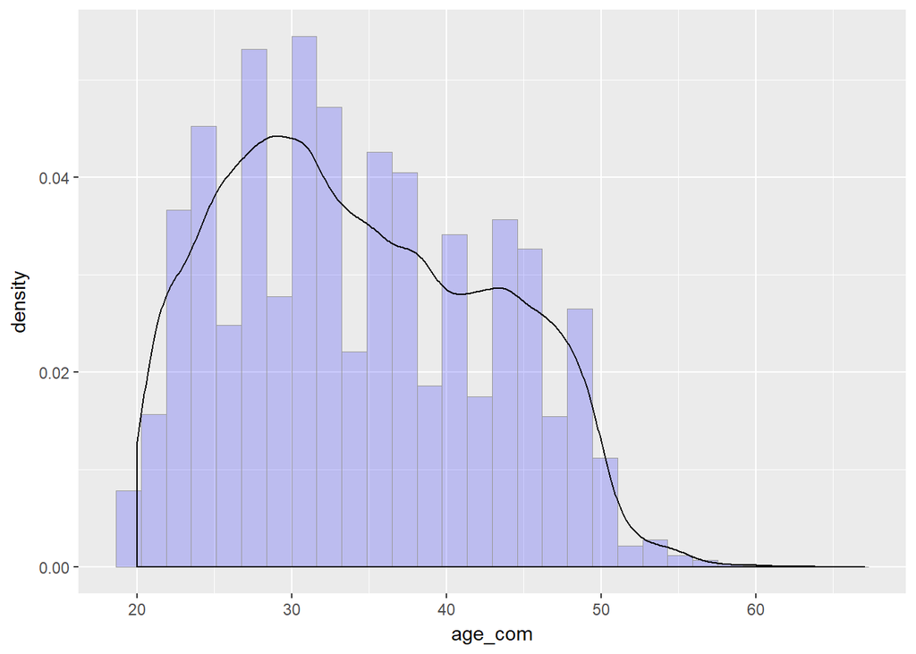

```r
library("ggplot2");
ggplot(traindata, aes(x = age_com, y = ..density..)) + geom_histogram(fill = "blue", colour = "grey60", size = 0.2, alpha = 0.2) + geom_density()
```

### 2.变量之间的相关性（共线性）

### >建模之前首先得检验变量之间（包括自变量和响应变量）的相关性，如果变量之间相关性显著，会影响模型的预测效果

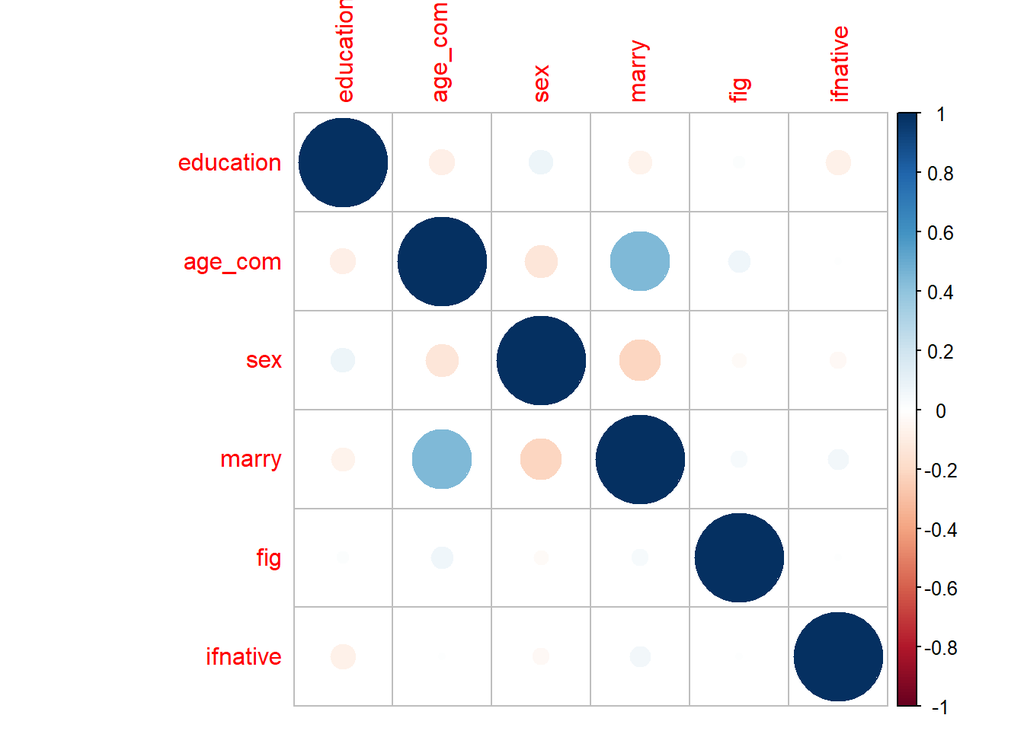

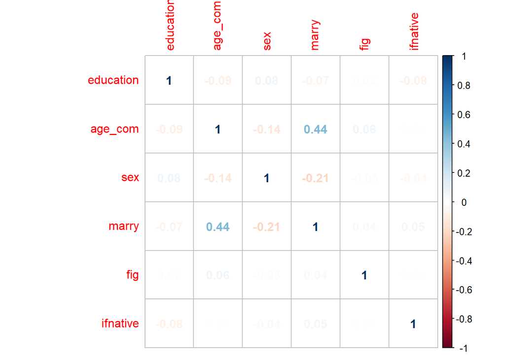

```r
library("corrplot");
cor1<-cor(traindata);
corrplot(cor1);corrplot(cor1,method="number");
```

### >从上面这两张相关系数矩阵图可以看到，各变量之间的相关性是非常小的（年龄和婚姻状况最高，但也只有0.44，可以接受），由于各自变量间的的相关性都较小，可以初步判断不存在多重共线性

## 三、切分数据集

```r
table(traindata$fig)
```

```
##
##     0     1
## 48250  2350
```

```r
library("caret")
```

```r
set.seed(1234)
splitIndex<-createDataPartition(traindata$fig,time=1,p=0.5,list=FALSE)
train<-traindata[splitIndex,]
test<-traindata[-splitIndex,]
prop.table(table(train$fig))
```

```
##
##          0          1
## 0.95458498 0.04541502
```

```r
prop.table(table(test$fig))
```

```
##
##          0          1
## 0.95252964 0.04747036
```

### >从上面两张表我们可以看到，随机拆分的分类结果是平衡的，仍有4.54%的代表，因此可以使用这份切割的数据进行建模及预测

## 四、Logistic回归（建立逻辑回归模型）

### >Logistic回归在信用评分卡开发中起到核心作用。由于其特点，以及对自变量进行了证据权重转换（WOE），Logistic回归的结果可以直接转换为一个汇总表，即所谓的标准评分卡格式。

### >1.首先利用glm函数对所有变量进行Logistic回归建模，模型如下：

```r
fit1<-glm(fig~.,train,family = "binomial")
summary(fit1)
```

```
##
## Call:
## glm(formula = fig ~ ., family = "binomial", data = train)
##
## Deviance Residuals:
##     Min       1Q   Median       3Q      Max
## -0.5371  -0.3331  -0.2949  -0.2603   2.7725
##
## Coefficients:
##              Estimate Std. Error z value Pr(>|z|)
## (Intercept) -4.295715   0.151080 -28.433  < 2e-16 ***
## education    0.470209   0.107330   4.381 1.18e-05 ***
## age_com      0.031212   0.003906   7.990 1.35e-15 ***
## sex         -0.150312   0.065827  -2.283   0.0224 *
## marry        0.067221   0.085195   0.789   0.4301
## ifnative     0.147154   0.071020   2.072   0.0383 *
## ---
## Signif. codes:  0 '***' 0.001 '**' 0.01 '*' 0.05 '.' 0.1 ' ' 1
##
## (Dispersion parameter for binomial family taken to be 1)
##
##     Null deviance: 9350.2  on 25299  degrees of freedom
## Residual deviance: 9242.5  on 25294  degrees of freedom
## AIC: 9254.5
##
## Number of Fisher Scoring iterations: 6
```

### >可以看出，利用全变量进行回归，模型拟合效果并不是很好，其中marry这个变量的p值未能通过检验，在此直接剔除这个变量，利用剩余的变量对fig进行回归，模型如下：

```r
fit2<-glm(fig~education+age_com+sex+ifnative,train,family = "binomial")
summary(fit2)
```

```
##
## Call:
## glm(formula = fig ~ education + age_com + sex + ifnative, family = "binomial",
##     data = train)
##
## Deviance Residuals:
##     Min       1Q   Median       3Q      Max
## -0.5402  -0.3320  -0.2925  -0.2597   2.7627
##
## Coefficients:
##             Estimate Std. Error z value Pr(>|z|)
## (Intercept) -4.28448    0.14999 -28.565  < 2e-16 ***
## education    0.46863    0.10731   4.367 1.26e-05 ***
## age_com      0.03242    0.00359   9.031  < 2e-16 ***
## sex         -0.15808    0.06512  -2.428   0.0152 *
## ifnative     0.14916    0.07097   2.102   0.0356 *
## ---
## Signif. codes:  0 '***' 0.001 '**' 0.01 '*' 0.05 '.' 0.1 ' ' 1
##
## (Dispersion parameter for binomial family taken to be 1)
##
##     Null deviance: 9350.2  on 25299  degrees of freedom
## Residual deviance: 9243.1  on 25295  degrees of freedom
## AIC: 9253.1
##
## Number of Fisher Scoring iterations: 6
```

### >第二个回归模型所有变量都通过了检验，其赤池值（AIC）也相对较小一些，所以模型的拟合效果更好些

### >2.模型检验

### >通常一个二值分类器可以通过ROC（Receiver Operating Characteristic）曲线和AUC值来评价优劣

```r
pre <- predict(fit2,test)
library("pROC")
```

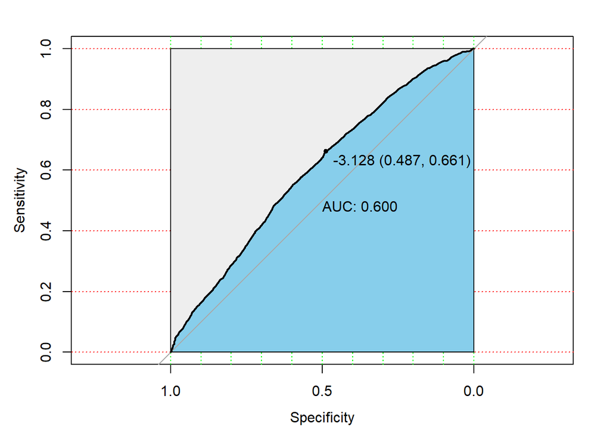

```r
modelroc <- roc(test$fig,pre)
plot(modelroc, print.auc=TRUE, auc.polygon=TRUE, grid=c(0.1, 0.2),
     grid.col=c("green", "red"), max.auc.polygon=TRUE,
     auc.polygon.col="skyblue", print.thres=TRUE)
```

### >如上图所示，AUC值只有0.6，说明该模型只有一定的预测准确性

## 五、WOE转换

### >证据权重（Weight of Evidence,WOE）转换可以将Logistic回归模型转变为标准评分卡格式

### >1.将四个变量进行分箱

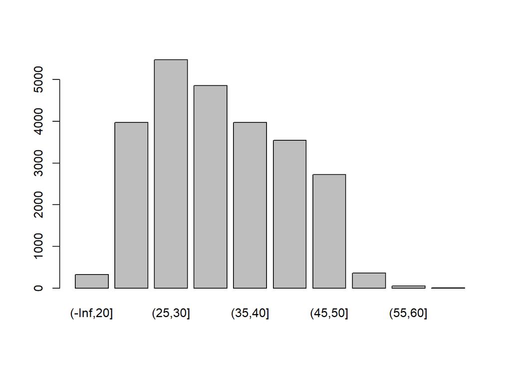

```r
 cutage_com= c(-Inf,20,25,30,35,40,45,50,55,60,Inf)
   plot(cut(train$age_com,cutage_com))
```

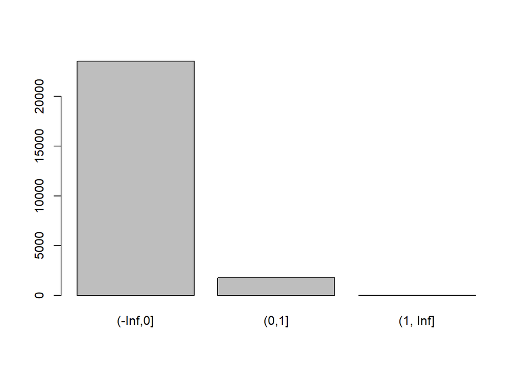

```r
 cuteducation= c(-Inf,0,1,Inf)
   plot(cut(train$education,cuteducation))
```

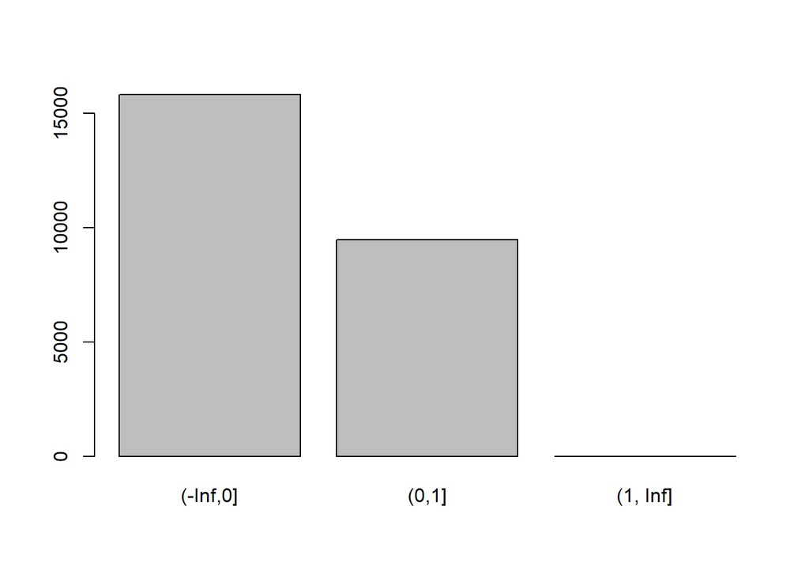

```r
 cutsex= c(-Inf,0,1,Inf)
   plot(cut(train$sex,cutsex))
```

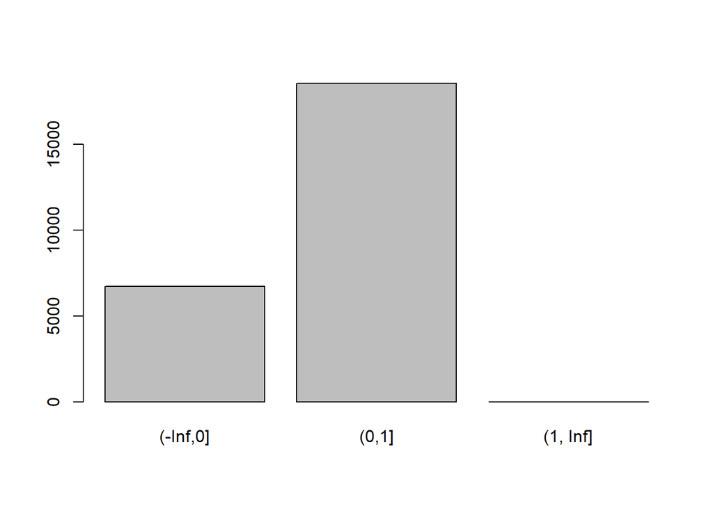

```r
 cutifnative= c(-Inf,0,1,Inf)
   plot(cut(train$ifnative,cutifnative))
```

### >2.计算权重（WOE值）

### >年龄

```r
   totalgood = as.numeric(table(train$fig))[1]
   totalbad = as.numeric(table(train$fig))[2]
   getWOE <- function(a,p,q)
   {
      Good <- as.numeric(table(train$fig[a > p & a <= q]))[1]
      Bad <- as.numeric(table(train$fig[a > p & a <= q]))[2]
      WOE <- log((Bad/totalbad)/(Good/totalgood),base = exp(1))
      return(WOE)
   }
   age_comlessthan20.WOE=getWOE(train$age_com,-Inf,20)
   age_com20to25.WOE=getWOE(train$age_com,20,25)
   age_com25to30.WOE=getWOE(train$age_com,25,30)
   age_com30to35.WOE=getWOE(train$age_com,30,35)
   age_com35to40.WOE=getWOE(train$age_com,35,40)
   age_com40to45.WOE=getWOE(train$age_com,40,45)
   age_com45to50.WOE=getWOE(train$age_com,45,50)
   age_com50to55.WOE=getWOE(train$age_com,50,55)
   age_com55to60.WOE=getWOE(train$age_com,55,60)
   age_commorethan.WOE=getWOE(train$age_com,60,Inf)
   age_com.WOE=c(age_comlessthan20.WOE,age_com20to25.WOE,age_com25to30.WOE,age_com30to35.WOE,age_com35to40.WOE,
            age_com40to45.WOE,age_com45to50.WOE,age_com50to55.WOE,age_com55to60.WOE,age_commorethan.WOE)
   age_com.WOE
```

```
##  [1] -0.50034482 -0.58058858 -0.24342258  0.04320095  0.19855281
##  [6]  0.24952834  0.23033618  0.51527055  1.03053077  1.43599588
```

### >学历

```r
   educationlessthan0.WOE=getWOE(train$education,-Inf,0)
   education0to1.WOE=getWOE(train$education,0,1)
   educationmorethan.WOE=getWOE(train$education,1,Inf)
   education.WOE=c(educationlessthan0.WOE,education0to1.WOE,educationmorethan.WOE)
   education.WOE
```

```
## [1] -0.02502203  0.29025769          NA
```

### >性别

```r
   sexlessthan0.WOE=getWOE(train$sex,-Inf,0)
   sex0to1.WOE=getWOE(train$sex,0,1)
   sexmorethan.WOE=getWOE(train$sex,1,Inf)
   sex.WOE=c(sexlessthan0.WOE,sex0to1.WOE,sexmorethan.WOE)
   sex.WOE
```

```
## [1]  0.0762474 -0.1405671         NA
```

### >是否本分公司行政区域内的人

```r
   ifnativelessthan0.WOE=getWOE(train$ifnative,-Inf,0)
   ifnative0to1.WOE=getWOE(train$ifnative,0,1)
   ifnativemorethan.WOE=getWOE(train$ifnative,1,Inf)
   ifnative.WOE=c(ifnativelessthan0.WOE,ifnative0to1.WOE,ifnativemorethan.WOE)
   ifnative.WOE
```

```
## [1] -0.10377849  0.03535537          NA
```

### >3.WOE变换

```r
 tmp.age <- 0
    for(i in 1:nrow(train)) {
      if(train$age_com[i] <= 20)
        tmp.age[i] <- age_comlessthan20.WOE
      else if(train$age_com[i] <= 25)
        tmp.age[i] <- age_com20to25.WOE
      else if(train$age_com[i] <= 30)
        tmp.age[i] <- age_com25to30.WOE
      else if(train$age_com[i] <= 35)
        tmp.age[i] <- age_com30to35.WOE
      else if(train$age_com[i] <= 40)
        tmp.age[i] <- age_com35to40.WOE
      else if(train$age_com[i] <= 45)
        tmp.age[i] <- age_com40to45.WOE
      else if(train$age_com[i] <= 50)
        tmp.age[i] <- age_com45to50.WOE
      else if(train$age_com[i] <= 55)
        tmp.age[i] <- age_com50to55.WOE
      else if(train$age_com[i] <= 60)
        tmp.age[i] <- age_com55to60.WOE
      else
        tmp.age[i] <- age_commorethan.WOE
    }
 tmp.education <- 0
    for(i in 1:nrow(train)) {
      if(train$education[i] <= 0)
        tmp.education[i] <- educationlessthan0.WOE
      else if(train$education[i] <= 1)
        tmp.education[i] <- education0to1.WOE
      else
        tmp.education[i] <- educationmorethan.WOE
    }
  tmp.sex <- 0
    for(i in 1:nrow(train)) {
      if(train$sex[i] <= 0)
        tmp.sex[i] <- sexlessthan0.WOE
      else if(train$sex[i] <= 1)
        tmp.sex[i] <- sex0to1.WOE
      else
        tmp.sex[i] <- sexmorethan.WOE
    }
   tmp.ifnative <- 0
    for(i in 1:nrow(train)) {
      if(train$ifnative[i] <= 0)
        tmp.ifnative[i] <- ifnativelessthan0.WOE
      else if(train$ifnative[i] <= 1)
        tmp.ifnative[i] <- ifnative0to1.WOE
      else
        tmp.ifnative[i] <- ifnativemorethan.WOE
    }

    table(tmp.age)
```

```
## tmp.age
## -0.580588578228701 -0.500344822231087 -0.243422575876913
##               3972                321               5479
## 0.0432009500850914  0.198552805457296  0.230336183389916
##               4860               3975               2725
##  0.249528339729636  0.515270546866055   1.03053076769991
##               3545                366                 51
##   1.43599587580808
##                  6
```

```r
    table(tmp.education)
```

```
## tmp.education
## -0.0250220315077517   0.290257694479571
##               23544                1756
```

```r
    table(tmp.sex)
```

```
## tmp.sex
## -0.140567103798302 0.0762473959137635
##               9472              15828
```

```r
    table(tmp.ifnative)
```

```
## tmp.ifnative
## -0.103778491602958 0.0353553731629382
##               6736              18564
```

### >4.WOE DataFrame构建

```r
trainWOE =cbind.data.frame(tmp.age,tmp.education,tmp.sex,tmp.ifnative)
```

## 六、评分卡的创建和实施

```r
trainWOE$y=train$fig
glm.fit = glm(y~.,data = trainWOE,family = binomial(link = logit))
summary(glm.fit)
```

```
##
## Call:
## glm(formula = y ~ ., family = binomial(link = logit), data = trainWOE)
##
## Deviance Residuals:
##     Min       1Q   Median       3Q      Max
## -0.6366  -0.3295  -0.2977  -0.2582   2.7956
##
## Coefficients:
##               Estimate Std. Error z value Pr(>|z|)
## (Intercept)   -3.04579    0.03063 -99.451  < 2e-16 ***
## tmp.age        1.01045    0.10846   9.316  < 2e-16 ***
## tmp.education  1.43612    0.33963   4.228 2.35e-05 ***
## tmp.sex        0.69661    0.30033   2.320   0.0204 *
## tmp.ifnative   1.16749    0.51028   2.288   0.0221 *
## ---
## Signif. codes:  0 '***' 0.001 '**' 0.01 '*' 0.05 '.' 0.1 ' ' 1
##
## (Dispersion parameter for binomial family taken to be 1)
##
##     Null deviance: 9350.2  on 25299  degrees of freedom
## Residual deviance: 9232.1  on 25295  degrees of freedom
## AIC: 9242.1
##
## Number of Fisher Scoring iterations: 6
```

```r
coe = (glm.fit$coefficients)
p <- 20/log(2)
q <- 600-20*log(15)/log(2)
Score=q + p*{as.numeric(coe[1])+as.numeric(coe[2])*tmp.age+as.numeric(coe[3])*tmp.education+as.numeric(coe[4])*tmp.sex+as.numeric(coe[5])*tmp.ifnative}
base <- q + p*as.numeric(coe[1])
base
```

```
## [1] 433.9791
```

### >1.对各变量进行打分

### >年龄

```r
    age_comlessthan20.SCORE = round(p*as.numeric(coe[2])*age_comlessthan20.WOE,0)
    age_com20to25.SCORE = round(p*as.numeric(coe[2])*age_com20to25.WOE,0)
    age_com25to30.SCORE = round(p*as.numeric(coe[2])*age_com25to30.WOE,0)
    age_com30to35.SCORE = round(p*as.numeric(coe[2])*age_com30to35.WOE,0)
    age_com35to40.SCORE = round(p*as.numeric(coe[2])*age_com35to40.WOE,0)
    age_com40to45.SCORE = round(p*as.numeric(coe[2])*age_com40to45.WOE,0)
    age_com45to50.SCORE = round(p*as.numeric(coe[2])*age_com45to50.WOE,0)
    age_com50to55.SCORE = round(p*as.numeric(coe[2])*age_com50to55.WOE,0)
    age_com55to60.SCORE = round(p*as.numeric(coe[2])*age_com55to60.WOE,0)
    age_commorethan.SCORE= round(p*as.numeric(coe[2])*age_commorethan.WOE,0)
    age.SCORE =c(age_comlessthan20.SCORE,age_com20to25.SCORE,age_com25to30.SCORE,age_com30to35.SCORE,age_com35to40.SCORE,age_com40to45.SCORE,age_com45to50.SCORE,age_com50to55.SCORE,age_com55to60.SCORE,age_commorethan.SCORE)
    age.SCORE
```

```
##  [1] -15 -17  -7   1   6   7   7  15  30  42
```

### >学历

```r
   educationlessthan0.SCORE=round(p*as.numeric(coe[3])*educationlessthan0.WOE,0)
   education0to1.SCORE=round(p*as.numeric(coe[3])*education0to1.WOE,0)
   educationmorethan.SCORE=round(p*as.numeric(coe[3])*educationmorethan.WOE,0)
   education.SCORE=c(educationlessthan0.SCORE,education0to1.SCORE,educationmorethan.SCORE)
   education.SCORE
```

```
## [1] -1 12 NA
```

### >性别

```r
   sexlessthan0.SCORE=round(p*as.numeric(coe[4])*sexlessthan0.WOE,0)
   sex0to1.SCORE=round(p*as.numeric(coe[4])*sex0to1.WOE,0)
   sexmorethan.SCORE=round(p*as.numeric(coe[4])*sexmorethan.WOE,0)
   sex.SCORE=c(sexlessthan0.SCORE,sex0to1.SCORE,sexmorethan.SCORE)
   sex.SCORE
```

```
## [1]  2 -3 NA
```

### >是否本分公司行政区域内的人

```r
   ifnativelessthan0.SCORE=round(p*as.numeric(coe[5])*ifnativelessthan0.WOE,0)
   ifnative0to1.SCORE=round(p*as.numeric(coe[5])*ifnative0to1.WOE,0)
   ifnativemorethan.SCORE=round(p*as.numeric(coe[5])*ifnativemorethan.WOE,0)
   ifnative.SCORE=c(ifnativelessthan0.SCORE,ifnative0to1.SCORE,ifnativemorethan.SCORE)
   ifnative.SCORE
```

```
## [1] -3  1 NA
```

### >3.最终生成的评分卡如下

```r
library("xlsx")
score_card1<-read.xlsx("score_card.xlsx",sheetIndex = 1,encoding = "UTF-8")
score_card1
```

[output not shown]

### 3.关于模型，AUC值为0.6，其实并不具有强的预测性，后续需要收集更多的营销员属性，诸如其家庭成员个数，负债率，第三方信用评分，微信好友个数，颜值评分等等多个维度（可要求入职时多填相关信息），持续调整数据结构，不断地训练和优化模型，我们才能够找到更加准确的绩优营销员的画像，从而实现定向增员，打造一支强有力的个险队伍，促进业务发展。

### 数据清洗过程源码可访问 https://github.com/JoeLee20188/XNPH 获取“FSL客户分析.sas”